# Factors that affect the Loan Outcome Status

## Preliminary Wrangling

This data set contains 113,937 loans with 81 variables on each loan, including loan amount, borrower rate (or interest rate), current loan status, borrower income, and many others.

```python
# import all packages and set plots to be embedded inline
import numpy as np
import pandas as pd
import matplotlib.pyplot as plt
import seaborn as sns

%matplotlib inline
```

```python
#load dataset
df = pd.read_csv('data.csv')
```

```python
df.head()
```

|  | ListingKey | ListingNumber | ListingCreationDate | CreditGrade | Term | LoanStatus | ClosedDate | BorrowerAPR | BorrowerRate | LenderYield | ... | LP_ServiceFees | LP_CollectionFees | LP_GrossPrincipalLoss | LP_NetPrincipalLoss | LP_NonPrincipalRecoverypayments | PercentFunded | Recommendations | InvestmentFromFriendsCount | InvestmentFromFriendsAmount | Investors |
| --- | --- | --- | --- | --- | --- | --- | --- | --- | --- | --- | --- | --- | --- | --- | --- | --- | --- | --- | --- | --- | --- |
| 0 | 1021339766868145413AB3B | 193129 | 2007-08-26 19:09:29.263000000 | C | 36 | Completed | 2009-08-14 00:00:00 | 0.16516 | 0.1580 | 0.1380 | ... | -133.18 | 0.0 | 0.0 | 0.0 | 0.0 | 1.0 | 0 | 0 | 0.0 | 258 |
| 1 | 10273602499503308B223C1 | 1209647 | 2014-02-27 08:28:07.900000000 | NaN | 36 | Current | NaN | 0.12016 | 0.0920 | 0.0820 | ... | 0.00 | 0.0 | 0.0 | 0.0 | 0.0 | 1.0 | 0 | 0 | 0.0 | 1 |
| 2 | 0EE9337825851032864889A | 81716 | 2007-01-05 15:00:47.090000000 | HR | 36 | Completed | 2009-12-17 00:00:00 | 0.28269 | 0.2750 | 0.2400 | ... | -24.20 | 0.0 | 0.0 | 0.0 | 0.0 | 1.0 | 0 | 0 | 0.0 | 41 |
| 3 | 0EF5356002482715299901A | 658116 | 2012-10-22 11:02:35.010000000 | NaN | 36 | Current | NaN | 0.12528 | 0.0974 | 0.0874 | ... | -108.01 | 0.0 | 0.0 | 0.0 | 0.0 | 1.0 | 0 | 0 | 0.0 | 158 |
| 4 | 0F023589499656230C5E3E2 | 909464 | 2013-09-14 18:38:39.097000000 | NaN | 36 | Current | NaN | 0.24614 | 0.2085 | 0.1985 | ... | -60.27 | 0.0 | 0.0 | 0.0 | 0.0 | 1.0 | 0 | 0 | 0.0 | 20 |

5 rows × 81 columns

```python
print(df.shape)
df.info()
```

```
(113937, 81)
<class 'pandas.core.frame.DataFrame'>
RangeIndex: 113937 entries, 0 to 113936
Data columns (total 81 columns):
 #   Column                               Non-Null Count   Dtype
---  ------                               --------------   -----
 0   ListingKey                           113937 non-null  object
 1   ListingNumber                        113937 non-null  int64
 2   ListingCreationDate                  113937 non-null  object
 3   CreditGrade                          28953 non-null   object
 4   Term                                 113937 non-null  int64
 5   LoanStatus                           113937 non-null  object
 6   ClosedDate                           55089 non-null   object
 7   BorrowerAPR                          113912 non-null  float64
 8   BorrowerRate                         113937 non-null  float64
```

[output cut: 74 more lines]

```python
#select columns needed for analysis
cols = ['ListingKey', 'BorrowerAPR', 'ProsperScore', 'TotalInquiries',
       'AvailableBankcardCredit', 'StatedMonthlyIncome', 'LoanOriginalAmount',
       'DebtToIncomeRatio', 'LoanStatus', 'EmploymentStatus', 'IsBorrowerHomeowner',
       'Term']

df = df[cols]
df.info()
```

```
<class 'pandas.core.frame.DataFrame'>
RangeIndex: 113937 entries, 0 to 113936
Data columns (total 12 columns):
 #   Column                   Non-Null Count   Dtype
---  ------                   --------------   -----
 0   ListingKey               113937 non-null  object
 1   BorrowerAPR              113912 non-null  float64
 2   ProsperScore             84853 non-null   float64
 3   TotalInquiries           112778 non-null  float64
 4   AvailableBankcardCredit  106393 non-null  float64
 5   StatedMonthlyIncome      113937 non-null  float64
 6   LoanOriginalAmount       113937 non-null  int64
 7   DebtToIncomeRatio        105383 non-null  float64
 8   LoanStatus               113937 non-null  object
 9   EmploymentStatus         111682 non-null  object
 10  IsBorrowerHomeowner      113937 non-null  bool
 11  Term                     113937 non-null  int64
dtypes: bool(1), float64(6), int64(2), object(3)
memory usage: 9.7+ MB
```

```python
#check duplicated
df.duplicated().sum()
```

```
0
```

No duplicated values.

```python
#check nulls
df.isnull().sum()
```

```
ListingKey                     0
BorrowerAPR                   25
ProsperScore               29084
TotalInquiries              1159
AvailableBankcardCredit     7544
StatedMonthlyIncome            0
LoanOriginalAmount             0
DebtToIncomeRatio           8554
LoanStatus                     0
EmploymentStatus            2255
IsBorrowerHomeowner            0
Term                           0
dtype: int64
```

```python
#create a copy
loan = df.copy()
```

```python
#drop rows with null values
loan.dropna(inplace=True)
```

```python
loan.info()
```

```
<class 'pandas.core.frame.DataFrame'>
Int64Index: 77557 entries, 1 to 113936
Data columns (total 12 columns):
 #   Column                   Non-Null Count  Dtype
---  ------                   --------------  -----
 0   ListingKey               77557 non-null  object
 1   BorrowerAPR              77557 non-null  float64
 2   ProsperScore             77557 non-null  float64
 3   TotalInquiries           77557 non-null  float64
 4   AvailableBankcardCredit  77557 non-null  float64
 5   StatedMonthlyIncome      77557 non-null  float64
 6   LoanOriginalAmount       77557 non-null  int64
 7   DebtToIncomeRatio        77557 non-null  float64
 8   LoanStatus               77557 non-null  object
 9   EmploymentStatus         77557 non-null  object
 10  IsBorrowerHomeowner      77557 non-null  bool
 11  Term                     77557 non-null  int64
dtypes: bool(1), float64(6), int64(2), object(3)
memory usage: 7.2+ MB
```

### What is the structure of your dataset?

There are 77,557 loan data in the dataset with 12 features (borrower APR, Prosper score, total inquiries, bank card credit, loan status, term and etc).

### What is/are the main feature(s) of interest in your dataset?

I'm most interested to find out the factors that will affect the status of the loan.

### What features in the dataset do you think will help support your investigation into your feature(s) of interest?

I would expect the Prosper score will have large impact on loan status. The higher the Prosper score, the higher the probability that a loan will be completed. Also, monthly income, debt-to-income ratio, loan original amount, employment status and homeowner will probably have some impact on the loan outcome.

## Univariate Exploration

Let's start our analysis with exploring each features in our dataset.

```python
#set the base color
base_color = sns.color_palette()[0]
```

#### Loan Status

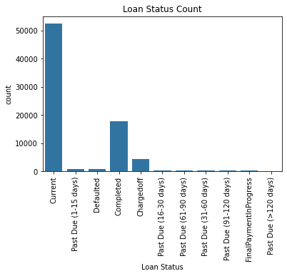

```python
sns.countplot(data=loan, x='LoanStatus', color=base_color)
plt.xlabel('Loan Status')
plt.title('Loan Status Count')
plt.xticks(rotation=90);
```

I will regroup the loan status into 3 groups for clearer visualisation: Current, Completed, High Risk. Therefore, the groups that are not under either Current or Completed will be regrouped under High Risk.

```python
loan['LoanStatus'].value_counts()
```

```
Current                   52478
Completed                 17703
Chargedoff                 4445
Defaulted                   885
Past Due (1-15 days)        722
Past Due (31-60 days)       327
Past Due (91-120 days)      277
Past Due (61-90 days)       275
Past Due (16-30 days)       242
FinalPaymentInProgress      189
Past Due (>120 days)         14
Name: LoanStatus, dtype: int64
```

```python
#rename value in column loan status
loan['LoanStatus'] = loan['LoanStatus'].replace({'Chargedoff' : 'High Risk',
                                                'Defaulted' : 'High Risk',
                                                'Past Due (1-15 days)' : 'High Risk',
                                                'Past Due (31-60 days)' : 'High Risk',
                                                'Past Due (91-120 days)' : 'High Risk',
                                                'Past Due (61-90 days)' :'High Risk',
                                                'Past Due (16-30 days)' : 'High Risk',
                                                'Past Due (>120 days)' : 'High Risk',
                                               'FinalPaymentInProgress' : 'Current'})
```

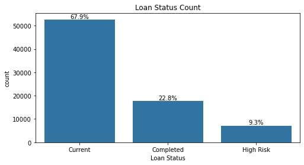

```python
n_listing = loan.shape[0]
listing_counts = loan['LoanStatus'].value_counts()

plt.figure(figsize=[8,4])
sns.countplot(data=loan, x='LoanStatus', color=base_color, order=loan['LoanStatus'].value_counts().index)
plt.xlabel('Loan Status')
plt.title('Loan Status Count')
locs, labels = plt.xticks(rotation=0)

for loc, label in zip(locs, labels):
    count=listing_counts[label.get_text()]
    pct_string = '{:0.1f}%'.format(100*count/n_listing)

    plt.text(loc, count+2, pct_string, ha='center', va = 'bottom', color='black');
```

#### Prosper Score

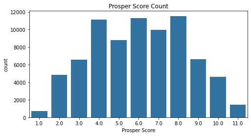

```python
plt.figure(figsize=[8,4])
sns.countplot(data=loan, x='ProsperScore', color=base_color)
plt.xlabel('Prosper Score')
plt.title('Prosper Score Count');
```

Most of the loan Prosper Score is within the range 4.0 and 8.0.

#### Borrower APR

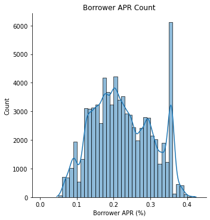

```python
bins = np.arange(0, loan['BorrowerAPR'].max()+0.01, 0.01)
sns.displot(loan['BorrowerAPR'], bins=bins, kde=True)
plt.xlabel('Borrower APR (%)')
plt.ylabel('Count')
plt.title('Borrower APR Count');
```

```python
loan.TotalInquiries.describe()
```

```
count    77557.000000
mean         4.334090
std          3.840599
min          0.000000
25%          2.000000
50%          3.000000
75%          6.000000
max         78.000000
Name: TotalInquiries, dtype: float64
```

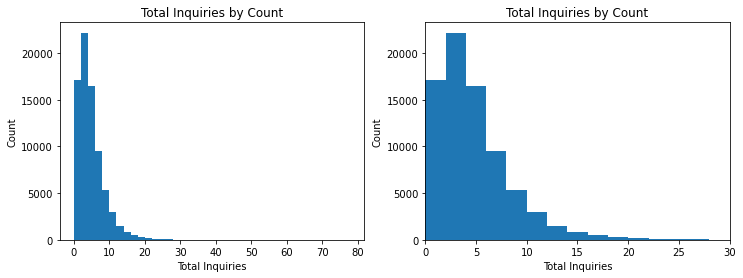

```python
bins = np.arange(0,80,2)

plt.figure(figsize=[12,4])

plt.subplot(1,2,1)
plt.hist(data=loan, x='TotalInquiries', bins=bins)
plt.xlabel('Total Inquiries')
plt.ylabel('Count')
plt.title('Total Inquiries by Count');

plt.subplot(1,2,2)
plt.hist(data=loan, x='TotalInquiries', bins=bins)
plt.xlim(0,30)
plt.xlabel('Total Inquiries')
plt.ylabel('Count')
plt.title('Total Inquiries by Count');
```

From the graph above, we can see that the total inquiries is heavily right skewed. This is due to some outliers in the distribution. I will proceed to remove any values which are 30 and above.

```python
loan.query('TotalInquiries >= 30')
```

|  | ListingKey | BorrowerAPR | ProsperScore | TotalInquiries | AvailableBankcardCredit | StatedMonthlyIncome | LoanOriginalAmount | DebtToIncomeRatio | LoanStatus | EmploymentStatus | IsBorrowerHomeowner | Term |
| --- | --- | --- | --- | --- | --- | --- | --- | --- | --- | --- | --- | --- |
| 179 | 0F1E35343868130956BD68F | 0.34731 | 1.0 | 34.0 | 8306.0 | 4583.333333 | 5500 | 0.13 | High Risk | Employed | True | 36 |
| 6027 | 956C3563862338243DD9FDE | 0.35797 | 1.0 | 35.0 | 3360.0 | 15000.000000 | 4000 | 0.37 | High Risk | Employed | True | 36 |
| 7011 | 53C23542977383898637385 | 0.35838 | 1.0 | 32.0 | 561.0 | 7083.333333 | 4000 | 0.28 | High Risk | Employed | True | 60 |
| 7370 | A3B53483646769822B5C768 | 0.38438 | 3.0 | 41.0 | 1233.0 | 6000.000000 | 1200 | 0.13 | High Risk | Full-time | True | 36 |
| 7562 | 2D8635981205945734A14D8 | 0.21166 | 4.0 | 41.0 | 3805.0 | 10416.666667 | 10500 | 0.30 | Current | Employed | False | 60 |
| ... | ... | ... | ... | ... | ... | ... | ... | ... | ... | ... | ... | ... |
| 107501 | 14BB34653394777122A8AA1 | 0.34215 | 2.0 | 33.0 | 32.0 | 5546.666667 | 1250 | 0.23 | High Risk | Full-time | False | 36 |
| 107630 | C7EB3554456220381F18963 | 0.35797 | 5.0 | 51.0 | 1108.0 | 7500.000000 | 4000 | 0.14 | Completed | Employed | True | 36 |
| 111017 | 29F935565637415348A8CA8 | 0.29310 | 1.0 | 43.0 | 10809.0 | 4333.333333 | 2000 | 0.20 | Completed | Employed | False | 12 |
| 112558 | D77B34656702857029CE992 | 0.37453 | 2.0 | 35.0 | 126.0 | 5800.000000 | 2000 | 0.39 | Completed | Full-time | True | 36 |
| 112986 | D53834732202586282F4BE1 | 0.37453 | 3.0 | 33.0 | 7.0 | 4300.000000 | 4100 | 0.40 | Completed | Full-time | False | 36 |

73 rows × 12 columns

```python
loan = loan[loan['TotalInquiries'] < 30]
```

```python
loan.TotalInquiries.describe()
```

```
count    77484.000000
mean         4.302191
std          3.687237
min          0.000000
25%          2.000000
50%          3.000000
75%          6.000000
max         29.000000
Name: TotalInquiries, dtype: float64
```

#### Available Bank Card Credit

```python
loan.AvailableBankcardCredit.describe()
```

```
count     77484.000000
mean      11148.168073
std       18227.183360
min           0.000000
25%        1112.000000
50%        4472.000000
75%       13515.250000
max      498374.000000
Name: AvailableBankcardCredit, dtype: float64
```

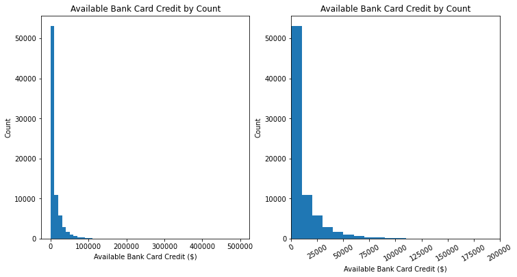

```python
bins = np.arange(0, loan['AvailableBankcardCredit'].max()+10000,10000)

plt.figure(figsize=[12,6])

plt.subplot(1,2,1)
plt.hist(data=loan, x='AvailableBankcardCredit', bins=bins)
plt.xlabel('Available Bank Card Credit ($)')
plt.ylabel('Count')
plt.title('Available Bank Card Credit by Count');

plt.subplot(1,2,2)
plt.hist(data=loan, x='AvailableBankcardCredit', bins=bins)
plt.xlim(0,200000)
plt.xlabel('Available Bank Card Credit ($)')
plt.ylabel('Count')
plt.title('Available Bank Card Credit by Count')
plt.xticks(rotation=30);
```

From the figure above, we can deduce that the majority of the borrower's available bank card credit is below 20,000. The distibution is heavily right skewed and has outliers. I will proceed to remove values above 200,000.

```python
loan.query('AvailableBankcardCredit >= 200000').count()
```

```
ListingKey                 40
BorrowerAPR                40
ProsperScore               40
TotalInquiries             40
AvailableBankcardCredit    40
StatedMonthlyIncome        40
LoanOriginalAmount         40
DebtToIncomeRatio          40
LoanStatus                 40
EmploymentStatus           40
IsBorrowerHomeowner        40
Term                       40
dtype: int64
```

```python
loan = loan[loan['AvailableBankcardCredit'] < 200000]
```

```python
loan.AvailableBankcardCredit.describe()
```

```
count     77444.000000
mean      11006.981897
std       17032.465639
min           0.000000
25%        1110.750000
50%        4466.000000
75%       13479.000000
max      195685.000000
Name: AvailableBankcardCredit, dtype: float64
```

#### Stated Monthly Income

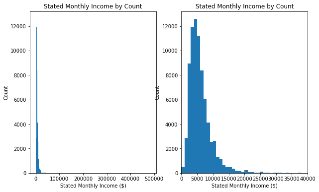

```python
bins = np.arange(0, loan['StatedMonthlyIncome'].max()+1000, 1000)

plt.figure(figsize=[10,6])

plt.subplot(1,2,1)
plt.hist(data=loan, x='StatedMonthlyIncome', bins=bins)
plt.xlabel('Stated Monthly Income ($)')
plt.ylabel('Count')
plt.title('Stated Monthly Income by Count');

plt.subplot(1,2,2)
plt.hist(data=loan, x='StatedMonthlyIncome', bins=bins)
plt.xlim(0,40000)
plt.xlabel('Stated Monthly Income ($)')
plt.ylabel('Count')
plt.title('Stated Monthly Income by Count');
```

```python
loan.query('StatedMonthlyIncome >= 40000')
```

|  | ListingKey | BorrowerAPR | ProsperScore | TotalInquiries | AvailableBankcardCredit | StatedMonthlyIncome | LoanOriginalAmount | DebtToIncomeRatio | LoanStatus | EmploymentStatus | IsBorrowerHomeowner | Term |
| --- | --- | --- | --- | --- | --- | --- | --- | --- | --- | --- | --- | --- |
| 1003 | 2E17358795283998052DC39 | 0.13799 | 10.0 | 3.0 | 26457.0 | 41666.666667 | 4000 | 0.03 | Current | Self-employed | True | 36 |
| 4691 | 29CD355548810550309CE80 | 0.12528 | 8.0 | 8.0 | 32061.0 | 75000.000000 | 13000 | 0.15 | Completed | Employed | True | 36 |
| 7577 | 5B9335614595099362D96A1 | 0.12528 | 9.0 | 4.0 | 9431.0 | 48204.916667 | 10000 | 0.06 | Current | Employed | True | 36 |
| 8066 | 37043512916744588463B5A | 0.35643 | 4.0 | 5.0 | 0.0 | 416666.666667 | 2000 | 0.00 | Completed | Employed | True | 36 |
| 10019 | EC0E359190611007899AD73 | 0.15783 | 8.0 | 8.0 | 27376.0 | 41666.666667 | 35000 | 0.12 | Current | Employed | True | 60 |
| ... | ... | ... | ... | ... | ... | ... | ... | ... | ... | ... | ... | ... |
| 108154 | 90E035744235135235F40EA | 0.14857 | 9.0 | 3.0 | 4995.0 | 52500.000000 | 21500 | 0.07 | Current | Employed | True | 36 |
| 109043 | 236C35857437846579E84E5 | 0.18214 | 7.0 | 3.0 | 14863.0 | 68750.000000 | 25000 | 0.08 | Current | Employed | True | 36 |
| 111265 | 825035817683098956309D0 | 0.20593 | 9.0 | 5.0 | 8041.0 | 108750.000000 | 12765 | 0.03 | Completed | Employed | False | 60 |
| 113270 | D3AF357238727540198D36B | 0.22712 | 6.0 | 2.0 | 10012.0 | 394400.000000 | 2000 | 0.00 | Current | Employed | False | 36 |
| 113422 | D6F5358564236959306F397 | 0.22712 | 4.0 | 5.0 | 21239.0 | 45833.333333 | 15000 | 0.07 | Current | Employed | True | 36 |

79 rows × 12 columns

```python
loan = loan[loan['StatedMonthlyIncome'] < 40000]
```

```python
loan['StatedMonthlyIncome'].describe()
```

```
count    77365.000000
mean      5886.861061
std       3614.766304
min          0.250000
25%       3519.416667
50%       5000.000000
75%       7166.666667
max      39953.333333
Name: StatedMonthlyIncome, dtype: float64
```

#### Loan Original Amount

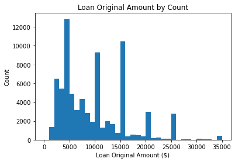

```python
bins = np.arange(0, loan['LoanOriginalAmount'].max()+1000, 1000)
plt.hist(data=loan, x='LoanOriginalAmount', bins=bins)
plt.xlabel('Loan Original Amount ($)')
plt.ylabel('Count')
plt.title('Loan Original Amount by Count');
```

The distribution loan amount looks multimodal, with peaks at 5000, 10000, 15000, 20000 and 25000. We also can notice that the popular loan amount follows pattern of multiple of 5000.

#### Debt-to-Income Ratio

```python
loan.DebtToIncomeRatio.describe()
```

```
count    77365.000000
mean         0.259012
std          0.318624
min          0.000000
25%          0.150000
50%          0.220000
75%          0.320000
max         10.010000
Name: DebtToIncomeRatio, dtype: float64
```

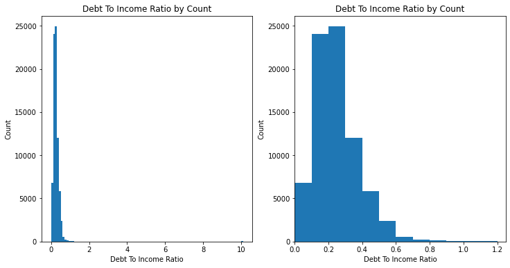

```python
bins = np.arange(0, loan['DebtToIncomeRatio'].max()+0.1, 0.1)

plt.figure(figsize=[12,6])

plt.subplot(1,2,1)
plt.hist(data=loan, x='DebtToIncomeRatio', bins=bins)
plt.xlabel('Debt To Income Ratio')
plt.ylabel('Count')
plt.title('Debt To Income Ratio by Count');

plt.subplot(1,2,2)
plt.hist(data=loan, x='DebtToIncomeRatio', bins=bins)
plt.xlabel('Debt To Income Ratio')
plt.ylabel('Count')
plt.title('Debt To Income Ratio by Count')
plt.xlim(0,1.25);
```

The figure above shows that the distribution is heavily right skewed and there are outliers in the dataset. When I zoom into the distribution by setting the x limit to (0-1.2), I found out that most of the borower keep their debt-to-income ratio at 0.1-0.3.

I will remove any values with Debt-to-income ratio larger or equal to 1.25 for better visualisation later.

```python
loan = loan[loan['DebtToIncomeRatio'] < 1.25]
```

#### Employment Status

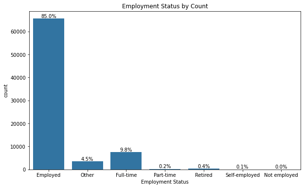

```python
n_listing = loan.shape[0]
listing_counts = loan['EmploymentStatus'].value_counts()

plt.figure(figsize=[10,6])
sns.countplot(data=loan, x='EmploymentStatus', color=base_color)
plt.xlabel('Employment Status')
plt.title('Employment Status by Count');


locs, labels = plt.xticks(rotation=0)

for loc, label in zip(locs, labels):
    count=listing_counts[label.get_text()]
    pct_string = '{:0.1f}%'.format(100*count/n_listing)

    plt.text(loc, count+2, pct_string, ha='center', va = 'bottom', color='black');
```

For distribution of employment status, we can see that 85% of the borrowers are under employment.

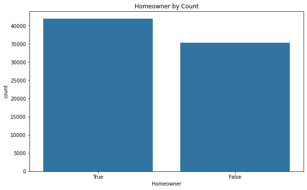

```python
plt.figure(figsize=[10,6])
sns.countplot(data=loan, x='IsBorrowerHomeowner', color=base_color, order=loan['IsBorrowerHomeowner'].value_counts().index)
plt.xlabel('Homeowner')
plt.title('Homeowner by Count');
```

From the graph above, we can see that more than 50% of the borrowers are homeowner.

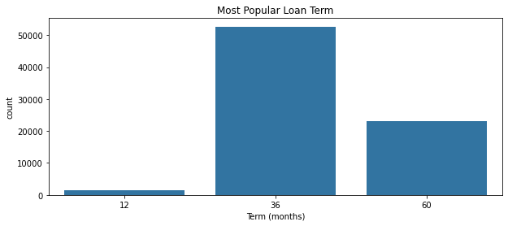

```python
plt.figure(figsize=[10,4])
sns.countplot(data=loan, x='Term', color=base_color)
plt.xlabel('Term (months)')
plt.title('Most Popular Loan Term');
```

So we can see that the most popular loan term is 36 months and least popular loan ter|m is 12 months.

```python
loan.info()
```

```
<class 'pandas.core.frame.DataFrame'>
Int64Index: 77160 entries, 1 to 113936
Data columns (total 12 columns):
 #   Column                   Non-Null Count  Dtype
---  ------                   --------------  -----
 0   ListingKey               77160 non-null  object
 1   BorrowerAPR              77160 non-null  float64
 2   ProsperScore             77160 non-null  float64
 3   TotalInquiries           77160 non-null  float64
 4   AvailableBankcardCredit  77160 non-null  float64
 5   StatedMonthlyIncome      77160 non-null  float64
 6   LoanOriginalAmount       77160 non-null  int64
 7   DebtToIncomeRatio        77160 non-null  float64
 8   LoanStatus               77160 non-null  object
 9   EmploymentStatus         77160 non-null  object
 10  IsBorrowerHomeowner      77160 non-null  bool
 11  Term                     77160 non-null  int64
dtypes: bool(1), float64(6), int64(2), object(3)
memory usage: 9.2+ MB
```

### Discuss the distribution(s) of your variable(s) of interest. Were there any unusual points? Did you need to perform any transformations?

The main feature of interest in this analysis is the loan status. We can see earlier it is categorised into more than 5 groups according to the overdue period. I have regrouped the data into 3 main groups (Current, High Risk and Completed) for clearer visualisation. There is no unusual points and thus no transformation was performed.

### Of the features you investigated, were there any unusual distributions? Did you perform any operations on the data to tidy, adjust, or change the form of the data? If so, why did you do this?

##### Total Inquiries

- The distribution is heavily skewed to the right and it is due to the outliers. I removed the values above 30, since only 73 data with total inquiries of 30 and above.

##### Available Bankcard Credit

- The distribution is heavily skewed to the right and it is due to the outliers. I removed the values above 200K, since only 40 data with credit of 200K and above.

## Bivariate Exploration

```python
numeric_vars = ['BorrowerAPR', 'ProsperScore', 'TotalInquiries', 'AvailableBankcardCredit', 'StatedMonthlyIncome',
               'LoanOriginalAmount', 'DebtToIncomeRatio']
categorical_vars = ['LoanStatus', 'EmploymentStatus', 'IsBorrowerHomeowner', 'Term']
```

#### Heatmap

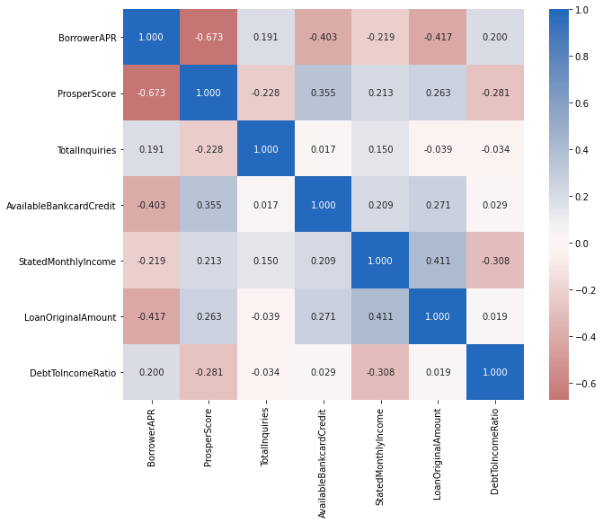

```python
plt.figure(figsize=[10,8])
sns.heatmap(loan[numeric_vars].corr(), annot=True, fmt='.3f', cmap = 'vlag_r', center=0);
```

#### Some siginificant relationships observed from the heatmap

##### ProsperScore

- Available Bankcard Credit, positive correlated (0.355)

Next, I will explore the relationship between numerical variables and categorical variables.

[output not shown]

[output cut: 32 more lines]

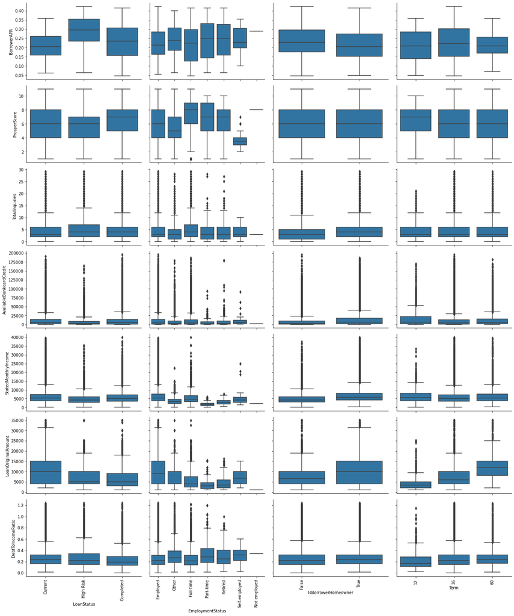

```python
def boxgrid(x, y, **kwargs):
    """ Quick hack for creating box plots with seaborn's PairGrid. """
    default_color = sns.color_palette()[0]
    sns.boxplot(x, y, color = default_color)
    plt.xticks(rotation=90)

plt.figure(figsize = [10, 10])
g = sns.PairGrid(data = loan, y_vars = numeric_vars,
                x_vars = ['LoanStatus', 'EmploymentStatus', 'IsBorrowerHomeowner', 'Term'], height = 3, aspect = 1.5)
g.map(boxgrid);
```

#### Observations from the above:

##### Loan Status

- APR for high risk is significantly higher than other 2 groups.
- Prosper Score for high risk group is lower.
- Total Inquiries for high risk group is slightly higher.
- Bank Credit and Monthly income are slightly lower for high risk group compared with other 2 groups.
- Loan amount of current group is the highest, but this could be due to the huge number of people in the 'Current' group.
- Debt-to-income ratio for completed group is slightly lower.

##### Employment Status

- APR for full time and employed group is lower compared to others.
- Prosper Score for self-employed group is the lowest.
- Total inquiries and bankcard credit look the same across all the groups.
- Monthly income of the employed group is slightly higher than others.
- Loan amount for part-time group is the lowest and employed group is the highest.
- Part-timers have slightly higher debt-to-income ratio

##### Term

- Loan amount and debt-to-income ratio increase as the term increases.
- There are no significant observations for other features.

From previous exploration, we knew that APR, Prosper score, available bankcard credit and monthly income are related to loan status.

Let's explore more on relationship between categorical variables.

#### Main Feature of Interest (Loan Status)

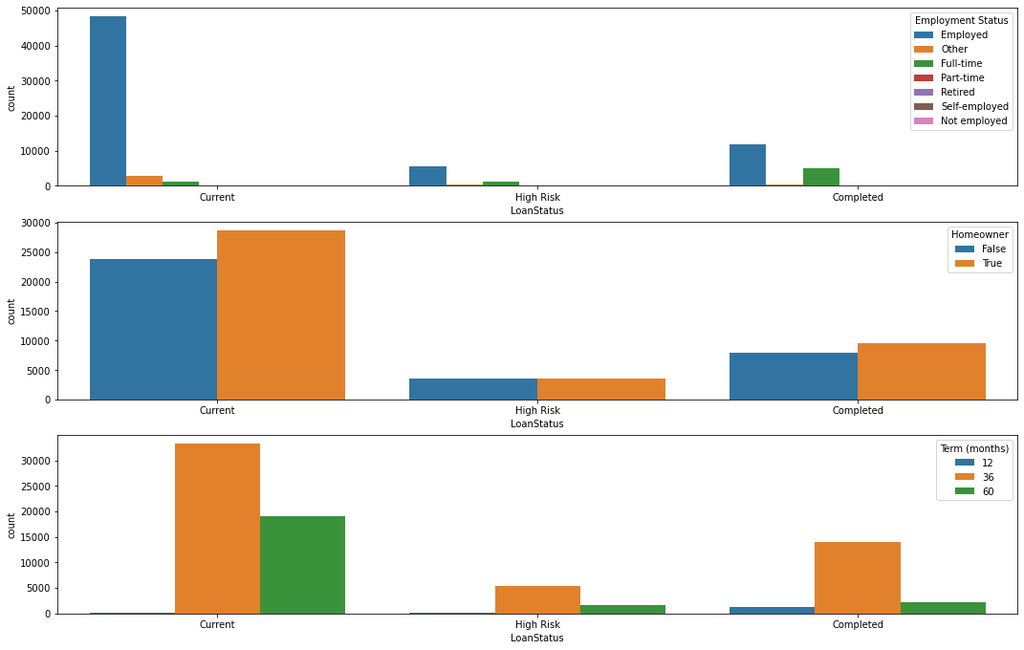

```python
plt.figure(figsize=[18,24])

plt.subplot(6,1,1)
sns.countplot(data=loan, x='LoanStatus', hue='EmploymentStatus')
plt.legend(title='Employment Status', loc='upper right')

plt.subplot(6,1,2)
sns.countplot(data=loan, x='LoanStatus', hue='IsBorrowerHomeowner')
plt.legend(title='Homeowner', loc='upper right');

plt.subplot(6,1,3)
sns.countplot(data=loan, x='LoanStatus', hue='Term')
plt.legend(title='Term (months)', loc='upper right');
```

From the graph above, we observed that::-

#### Homeowner

- The number of homeowner who completed the loan is higher than non-homeowner.
- However, the number of high risk group is the same for both homeowner and non-homeowner.

There is no significant relationship that can be observed from other features.

#### Other Features

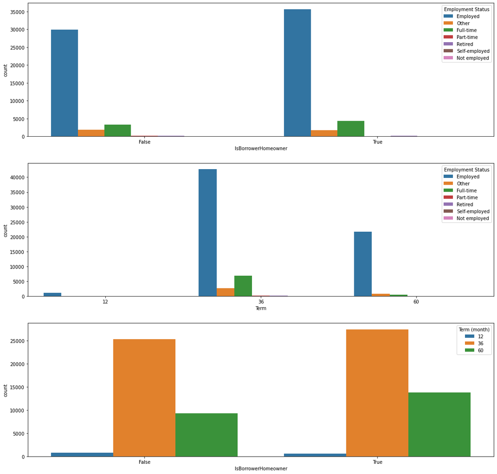

```python
plt.figure(figsize=[18,18])


plt.subplot(3,1,1)
sns.countplot(data=loan, x='IsBorrowerHomeowner', hue='EmploymentStatus')
plt.legend(title='Employment Status', loc='upper right');

plt.subplot(3,1,2)
sns.countplot(data=loan, x='Term', hue='EmploymentStatus')
plt.legend(title='Employment Status', loc='upper right');

plt.subplot(3,1,3)
sns.countplot(data=loan, x='IsBorrowerHomeowner', hue='Term')
plt.legend(title='Term (month)', loc='upper right');
```

From figure above, we observed that:

- Only employed group apply for 12 months loan.
- Employed and full timers prefer loan term of 36 months.

There is no significant relationship that can be observed from other features.

### Did you observe any interesting relationships between the other features (not the main feature(s) of interest)?

Some interesting relationships between other features observed:-

- Borrower APR and Prosper score has a negative correlation, which implies the higher the Prosper score, the lower the APR.
- Borrower APR and bankcard credit is negative correlated. This means that the APR will be brought down if the borrower has high available bankcard credit.
- The loan original amount has negative relationship with borrower APR.
- The Prosper score is postively correlated with available bankcard credit. This implies that the higher the bankcard credit, the higher the Prosper score and the person may enjoy low APR.
- Loan original amount is positively correlated with stated monthly income.

## Multivariate Exploration

From previous section, we know that there are a few significant relationships between the numerical variables. Now, I would like to add in the factor of the loan status to see how this affect the distribution.

As the dataset is too large, I select a sample of 200 data for better visualisation.

```python
np.random.seed(2018)
sample = np.random.choice(loan.shape[0], 200, replace=False)
loan_subset = loan.iloc[sample]
```

#### Relationship between Loan Status, Prosper Score and Borrower APR

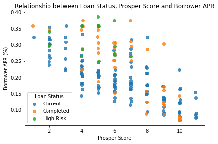

```python
g = sns.FacetGrid(data=loan_subset, hue='LoanStatus', height=4, aspect=1.5)
g.map(sns.regplot, 'ProsperScore', 'BorrowerAPR', x_jitter=0.04, fit_reg=False)

plt.legend(title='Loan Status')
plt.xlabel('Prosper Score')
plt.ylabel('Borrower APR (%)')
plt.title('Relationship between Loan Status, Prosper Score and Borrower APR');
```

From the graph above, we can see that the Prosper score of the high risk group is between 2-7. The borrower APR of this group is above 0.25%, which is quite high compared to others.

#### Relationship between Loan Status, Available Bankcard Credit and Borrower APR

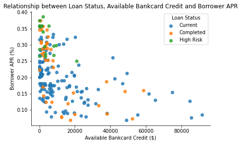

```python
g = sns.FacetGrid(data=loan_subset, hue='LoanStatus', height=4, aspect=1.5)
g.map(sns.regplot, 'AvailableBankcardCredit', 'BorrowerAPR', x_jitter=0.04, fit_reg=False)

plt.legend(title='Loan Status')
plt.xlabel('Available Bankcard Credit ($)')
plt.ylabel('Borrower APR (%)')
plt.title('Relationship between Loan Status, Available Bankcard Credit and Borrower APR');
```

So from the figure above, we observed that the bankcard credit for the high risk group is generally below $20,000 at APR of 0.25% - 0.4%.

#### Relationship between Loan Status, Loan Original Amount and Borrower APR

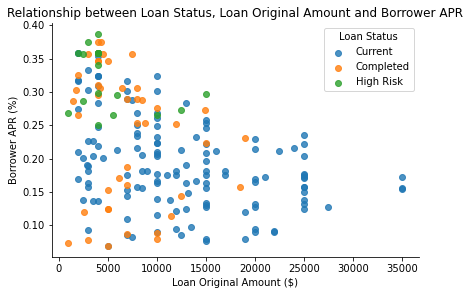

```python
g = sns.FacetGrid(data=loan_subset, hue='LoanStatus', height=4, aspect=1.5)
g.map(sns.regplot, 'LoanOriginalAmount', 'BorrowerAPR', x_jitter=0.04, fit_reg=False)

plt.legend(title='Loan Status')
plt.xlabel('Loan Original Amount ($)')
plt.ylabel('Borrower APR (%)')
plt.title('Relationship between Loan Status, Loan Original Amount and Borrower APR');
```

The loan original amount the high risk group borrow is not more than 15,000 dollar and APR between 0.25% - 0.4%.

#### Relationship between Loan Status, Loan Original Amount and Stated Monthly Income

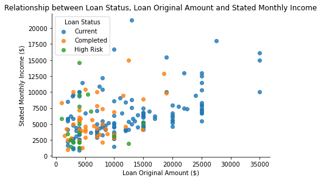

```python
g = sns.FacetGrid(data=loan_subset, hue='LoanStatus', height=4, aspect=1.5)
g.map(sns.regplot, 'LoanOriginalAmount', 'StatedMonthlyIncome', x_jitter=0.04, fit_reg=False)

plt.legend(title='Loan Status')
plt.xlabel('Loan Original Amount ($)')
plt.ylabel('Stated Monthly Income ($)')
plt.title('Relationship between Loan Status, Loan Original Amount and Stated Monthly Income');
```

The monthly income of the high risk group generally earns not more than 10,000 dollar and take up loan not more than 15,000 dollar.

#### Relationship between Loan Status, Homeownership and Prosper Score

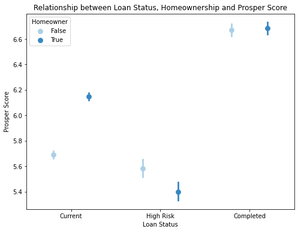

```python
plt.figure(figsize=[8,6])
sns.pointplot(data=loan, x='LoanStatus', y='ProsperScore', hue='IsBorrowerHomeowner', linestyles='', dodge=0.4, palette='Blues')
plt.legend(title='Homeowner')
plt.xlabel('Loan Status')
plt.ylabel('Prosper Score')
plt.title('Relationship between Loan Status, Homeownership and Prosper Score');
```

Current Group

- Homeowner has higher Prosper score than not a homeowner.
- Not-a-homeowner's Prosper score is almost equal to high risk not-a-homeowner.

High Risk Group

- Homeowner has the lowest Prosper score among all.

Completed Group

- The Prosper score is almost the same regardless of the homeownership.

#### Relationship between Loan Status, Homeownership and Borrower APR

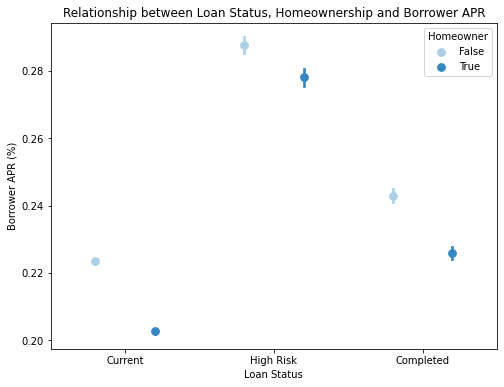

```python
plt.figure(figsize=[8,6])
sns.pointplot(data=loan, x='LoanStatus', y='BorrowerAPR', hue='IsBorrowerHomeowner', linestyles='', dodge=0.4, palette='Blues')
plt.legend(title='Homeowner')
plt.xlabel('Loan Status')
plt.ylabel('Borrower APR (%)')
plt.title('Relationship between Loan Status, Homeownership and Borrower APR');
```

Homeowners enjoys lower APR across all the groups (Current, High Risk and Completed).

#### Relationship between Loan Status, Homeownership and Available Bankcard Credit

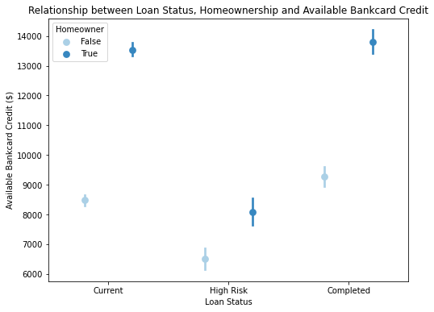

```python
plt.figure(figsize=[8,6])
sns.pointplot(data=loan, x='LoanStatus', y='AvailableBankcardCredit', hue='IsBorrowerHomeowner', linestyles='', dodge=0.4, palette='Blues')
plt.legend(title='Homeowner')
plt.xlabel('Loan Status')
plt.ylabel('Available Bankcard Credit ($)')
plt.title('Relationship between Loan Status, Homeownership and Available Bankcard Credit');
```

For Current and Completed:

- The available bankcard credit is extremely higher for homeowner compared to not-a-homeowner.

For High Risk:

- The available bankcard credit is higher for homeowner, but the difference is not that large as other groups.

#### Relationship between Loan Status, Homeownership and Loan Original Amount

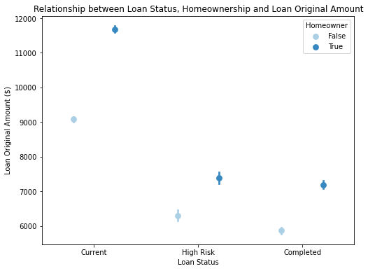

```python
plt.figure(figsize=[8,6])
sns.pointplot(data=loan, x='LoanStatus', y='LoanOriginalAmount', hue='IsBorrowerHomeowner', linestyles='', dodge=0.4, palette='Blues')
plt.legend(title='Homeowner')
plt.xlabel('Loan Status')
plt.ylabel('Loan Original Amount ($)')
plt.title('Relationship between Loan Status, Homeownership and Loan Original Amount');
```

Homeowners generally borrows higher amount of loan across all 3 groups.

#### Relationship between Loan Status, Homeownership and Stated Monthly Income

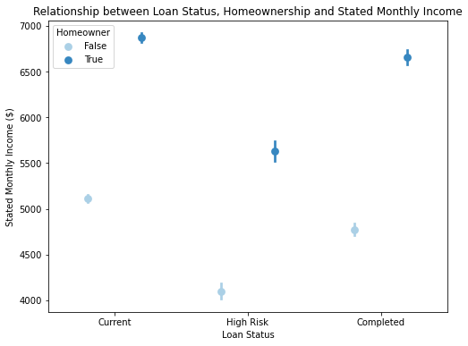

```python
plt.figure(figsize=[8,6])
sns.pointplot(data=loan, x='LoanStatus', y='StatedMonthlyIncome', hue='IsBorrowerHomeowner', linestyles='', dodge=0.4, palette='Blues')
plt.legend(title='Homeowner')
plt.xlabel('Loan Status')
plt.ylabel('Stated Monthly Income ($)')
plt.title('Relationship between Loan Status, Homeownership and Stated Monthly Income');
```

Homeowner generally earns more than not-a-homeowner across all 3 groups.

### Talk about some of the relationships you observed in this part of the investigation. Were there features that strengthened each other in terms of looking at your feature(s) of interest?

The main feature of interest in this data analysis is to identify the factors that will affect a loan outcome.

So from our multivariate analysis, we conclude the followings:-

- The Prosper score for the high risk group is between 2.0 to 7.0.
- The borrower APR for high risk group is generally higher, at around 0.25% to 0.4%.
- The available bankcard credit for high risk group is generally below 20,000 dollar.
- The high risk group usually borrows an amount of not more than 15,000 dollar.
- The high risk group generally earns a monthly income of not more than 10,000 dollar.

## Were there any interesting or surprising interactions between features?

While exploring the relationship between Prosper Score, Homeowner and Loan status, we noticed that:-

For Current Group

- Homeowner has higher Prosper score than not a homeowner.
- Not-a-homeowner's Prosper score is almost equal to high risk not-a-homeowner.

High Risk Group

- Homeowner has the lowest Prosper score among all.

Completed Group

- The Prosper score is almost the same regardless of the homeownership.

Surprisingly we found that for not-a-homeowner, the Prosper score is almost the same for both current and high risk group. And the Prosper score of these 2 group is even higher than high risk homeowner.

#### Save the template to csv file for explanatory analysis

```python
loan.to_csv('LoanDataClean.csv')
```